# Analysis of Cyclistic Bikeshare’s User Data

Abdulmalik Mohammed

2024-02-29

## **Background**

Cyclistic, a bike-share company launched in 2016 has now grown to a fleet of 5,824 bicycles and 692 stations across Chicago. Users can be grouped into “casual riders” (purchase single-ride or full-day passes) and “annual members”.

The company’s finance analysts concluded that annual members generate more profit. The director of marketing, Lily Moreno believes that an ad campaign to convert casual riders to annual members would be optimum, as they already aware of and have chosen Cyclistic for their mobility needs.

I have been tasked with answering the question “How do annual members and casual riders use Cyclistic bikes differently?”

### **Business Task**

How do casual riders and annual members use Cyclistic bikes differently?

### **Preparing and Cleaning Data for Analysis**

To answer this question, I collected the data from January to December 2023 from [here](https://divvy-tripdata.s3.amazonaws.com/index.html). The data has been made available by Motivate International Inc. under this [license](https://www.divvybikes.com/data-license-agreement). Data privacy prevents me from accessing any of the users’ personal information. This historical data from the previous year is reliable, original, comprehensive, cited and current thus making it suitable for this analysis.

### **Preparation**

I chose RStudio to work with the data, as it is best equipped to work with datasets as large as these. The 12 data sets contain 13 columns and about **160,000** to **780,000** rows. Some of the columns had datetime values stored as characters so I saved all the data sets as excel workbooks before uploading to Rstudio and merging them into a data frame `trip_data`

```r
library(tidyverse)
library(readxl)

jan_2023 <- read_excel("jan_2023.xlsx")
feb_2023 <- read_excel("feb_2023.xlsx")
mar_2023 <- read_excel("mar_2023.xlsx")
apr_2023 <- read_excel("apr_2023.xlsx")
may_2023 <- read_excel("may_2023.xlsx")
jun_2023 <- read_excel("jun_2023.xlsx")
jul_2023 <- read_excel("jul_2023.xlsx")
aug_2023 <- read_excel("aug_2023.xlsx")
sep_2023 <- read_excel("sep_2023.xlsx")
oct_2023 <- read_excel("oct_2023.xlsx")
nov_2023 <- read_excel("nov_2023.xlsx")
dec_2023 <- read_excel("dec_2023.xlsx")

trip_data <- jan_2023 %>%
  bind_rows(feb_2023) %>%
  bind_rows(mar_2023) %>%
  bind_rows(apr_2023) %>%
  bind_rows(may_2023) %>%
  bind_rows(jun_2023) %>%
  bind_rows(jul_2023) %>%
  bind_rows(aug_2023) %>%
  bind_rows(sep_2023) %>%
  bind_rows(oct_2023) %>%
  bind_rows(nov_2023) %>%
  bind_rows(dec_2023)
```

The merged data has the same number of columns and **5,693,156** rows. It contains information such as ride IDs, start and end station names and longitude and latitude of start and end stations

### **Processing**

Below is a summary of all the steps taken in the data cleaning and manipulation processes. The code can be viewed in my [GitHUB repository](https://github.com/manlikemal16/Cyclistic-Bike-Share-Exploratory-Analysis).

- I viewed the column names and changed the heading of the **member_casual** column to **user_type**.
- I dropped columns that were irrelevant to the analysis i.e the **end_station_id**, **start_station_id**, **end_lng**, **end_lat**, **start_lng** and **start_lat** columns.
- I checked the dataset for null values with the `apply()` function. I discovered there were **848995** records and **916658** records missing from the start and end station names respectively. These records were removed as the names are necessary for the analysis.
- I checked for any spelling errors in the **rideable_type** and **user_type** columns with `unique()`. No inconsistencies were found in either column.
- To begin answering the business task, I created a column **ride_length** which contains the duration of each ride in minutes. I created a **start_hour** column to show the time of day for each ride
- I checked the minimum, maximum and average trip durations. The minimum was a negative value and the maximum was way too long for a trip. I removed all the outliers from the data set by calculating the interquartile range.
- I included the columns **weekday** and **weekdaynum** to show what day of the week a ride took place. I also included a **month** column to better aggregate the data.

The cleaned data frame now contains **3,931,001** rows and 12 columns

### **Analysis**

In the Analysis phase of my work, I calculated summary statistics that would help answer the business question. Some of which were:

- Calculating the total number of trips taken by casual riders and annual members in 2023, then the average duration of their trips in minutes as a group and for each day. I also calculated bike type usage for each group.
- Calculating the number of trips for each day at the different times as I wanted to see what days and at what times of the day each group rode more.
- Calculating the number of trips taken by each user type for the different months to see the monthly trend.
- Finally I calculated the number of trips per start and end station to see the stations with the most takeoffs and those most visited by each group.

### **Data Visualisation**

For my data Visualisation I exported the results from my analysis as csv files and used **Tableau Public Desktop** to create a [dashboard](https://public.tableau.com/app/profile/abdulmalik.mohammed6137/viz/CyclisticBikeShare_18088278734110/CyclisticBikeShareDashboard) to display my findings.

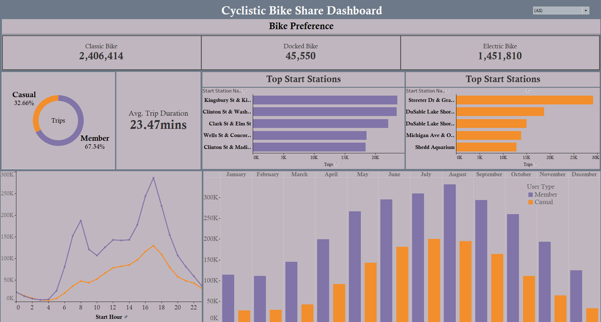

### **Insights and Recommendations**

**Insights**

- As expected, Cyclilstic is mostly used by annual members as they made up **67.34%** of the total trips for the past year. Both user groups enjoy Classic bikes the most but only casual users make use of Docked bikes. Despite annual members making up more than 50% of the customer base, casual users still take longer trips on average, especially on weekends

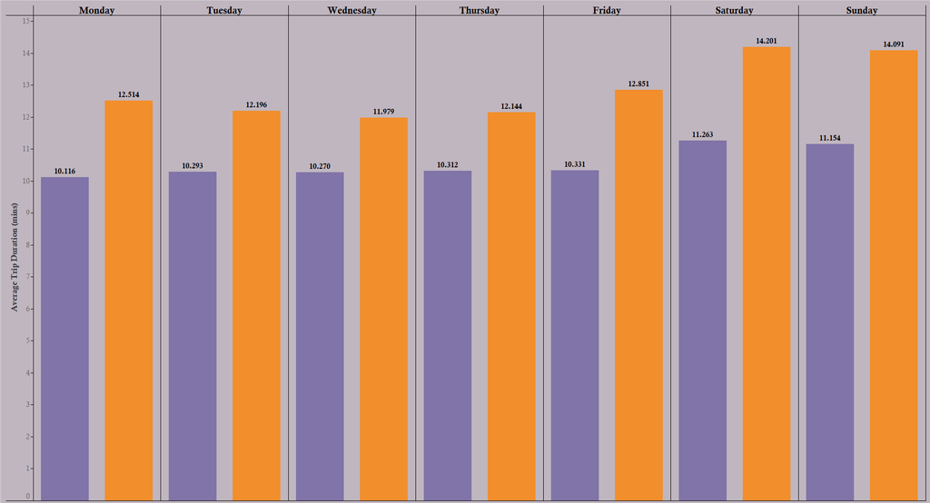

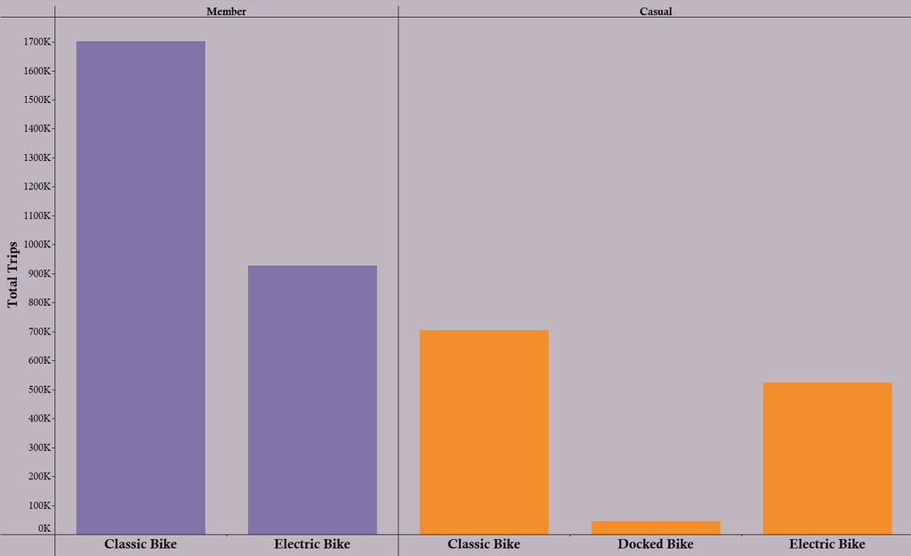

- Annual members typically use Cyclistic most around 7 to 8 AM and 4 to 5 PM. This suggests they are using the service mostly to commute to work and then back home. Casual riders however only have peak usage around 5PM which suggests they ride mostly in their leisure time. Both users groups have a surge of trips in the summer (June to August)

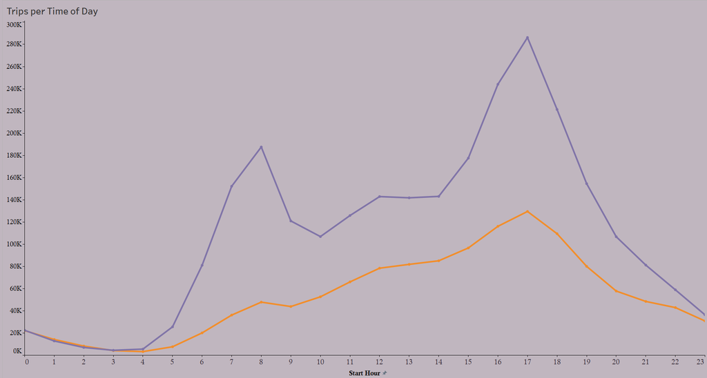

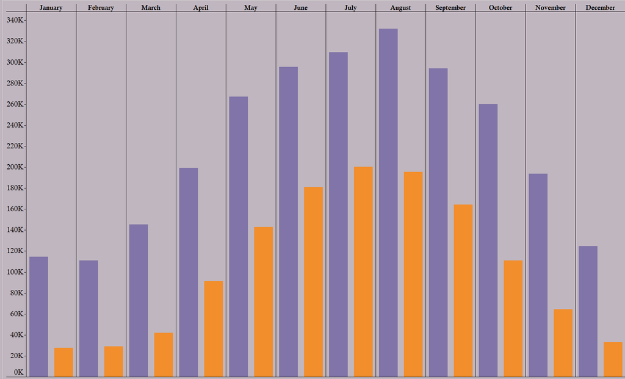

- From the start station analysis, the top stations used by casual members are as shown below.

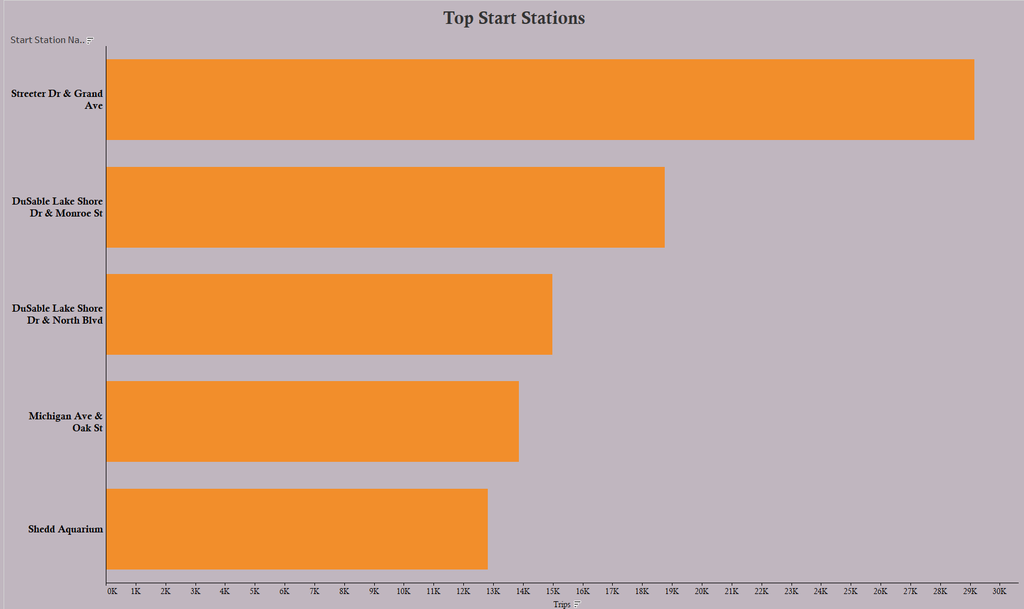

**Recommendations**

From the findings above, here are some recommendations that could prove useful in converting casual riders to annual members

- Cyclistic can offer a subscription plan with some benefits to users who go on evening trips, weekend trips and also take longer rides.
- Marketing efforts should be increased in the top stations used by the casual riders in the summer to showcase the new subscription offer.

**Thank you for reading! Stay tuned for the next data journey**

## **References**

**Eyitayo, O.** 2023. Google Data Analytics Capstone Project: Cyclistic Bike-Share Case Study

### **Contact Info**

- Whatsapp: **[+2348187893723](https://wa.me/08187893723)**
- Email: **malike1328@gmail.com**